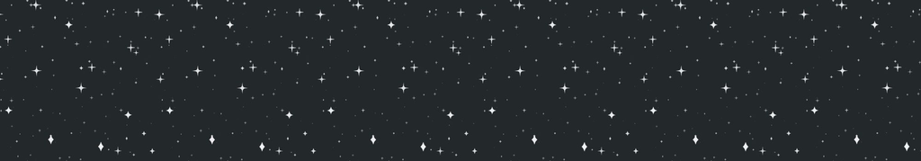

# IBM's Qiskit - Quantum Explorers 2023-2024

## Badge #1: Captain - Quantum Computing and Qiskit 101

- **Story**
- **Instructions**
- **Quiz**
- **Unlock Your Badge**

## Story

[figure not shown]

A magnificent Heron-class starship, equipped with faster-than-light travel capabilities, comfortable amenities, weapons, and an enthusiastic crew needs a captain. You are an esteemed explorer and are perfect for the job. Your starship-to-be is called the ESS - Loki.

*(ESS stands for “Earth Starship”. Share your starship’s name in the* *[#space-exploration channel on Discord!](https://discord.com/channels/979714492533440533/1108653145116131338)** )*

Complete this module to become Captain, ensure a successful launch into space, and become humanity’s leading space exploration pioneer.

## Instructions

The Captain badge is a learning badge, which means this is a learning module.

### Tasks to complete to unlock this achievement

1. Go through the Captain syllabus at your own pace. The syllabus has study materials, labs, exercises, and resources.
   - The **[Captain badge workbook](https://ibm.box.com/v/qe23-captain-82)** is a downloadable PDF that includes the syllabus, has interactable checkboxes, and note sections. You can use this to track your progress and take notes.
   - An **[online version of only the syllabus](https://learn.qiskit.org/syllabus/SFH-RXE)** has been created for your convenience as well.
2. Once you think you're ready to unlock the badge, please take the quiz. You may attempt the quiz as many times as you like.

For any questions or discussions about the Captain badge and its material, please use the **[#q-computing-101](https://discord.com/channels/979714492533440533/1096012050209181826)** channel on Discord.

**Important Links**

- **[Captain workbook](https://ibm.box.com/v/qe23-captain-82)**
- **[Online version of the syllabus](https://learn.qiskit.org/syllabus/SFH-RXE)**
- **[#q-computing-101 Discord channel](https://discord.com/channels/979714492533440533/1096012050209181826)**

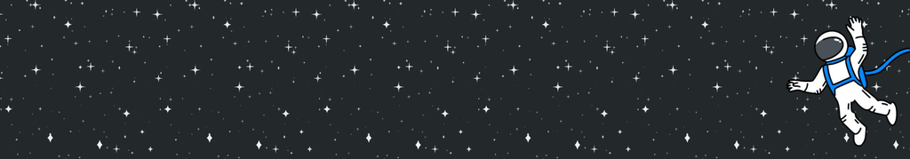

## Quiz

Ready to take the quiz?

For the multiple choice questions, choose the correct answer from the given list. There is only one correct answer. The answer must be a **list with an integer** denoting the option number. If you think all options are wrong, you can just pass an empty list.

For the coding question, please fill in the relevant Qiskit code as instructed.

### Scoring

- Multiple choice questions are worth 1 point each.
- The coding question is worth 3 points.
- Extra credit questions are worth 1 point each.
- You must hit 12 points or more to pass.
- You will *not* be informed whether your answer is correct, except for the coding question.

Your score will be revealed at the end in the "Unlock Your Badge" section as a percentage. **Passing score is 80%.** Note: since there are extra credit questions, you may get over 100%!

**Question 1: The goal is to reach the state $|1⟩$. Which gate do you apply?**

Choose the correct answer from the following list. There is only one correct answer.

1. H gate.
2. Z gate.
3. X gate.
4. Y gate.

The answer must be a **list with an integer** denoting the option number. If you think all options are wrong, you can just pass an empty list.

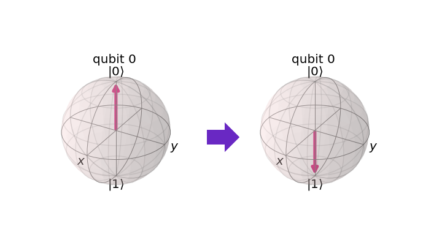

```python
# build your code here
answer1 = [3]
```

```python
# run this cell to submit your answer

# import the grader for the exercise 1 of the lab/badge 1
from qc_grader.challenges.quantum_explorers23 import grade_badge1_ex1

# expected result type: List
grade_badge1_ex1(answer1)
```

```
Submitting your answer. Please wait...
Thank you for submitting your answer. Your answer has been recorded and, if correct, will count towards your final score.
```

**Question 2: Even if you know everything about a quantum state, it can still behave randomly.**

1. True.
2. False.

```python
# build your code here
answer2 = [1]
```

```python
# eun this cell to submit your answer

# import the grader for the exercise 2 of the lab/badge 1
from qc_grader.challenges.quantum_explorers23 import grade_badge1_ex2

# expected result type: List
grade_badge1_ex2(answer2)
```

```
Submitting your answer. Please wait...
Thank you for submitting your answer. Your answer has been recorded and, if correct, will count towards your final score.
```

**Question 3: We would like to create superposition. The goal is to reach the state $|+\rangle = \frac{1}{\sqrt{2}}(|0\rangle + |1\rangle )$ . Which gate do you apply?**

1. X gate.
2. Y gate.
3. Z gate.
4. H gate.

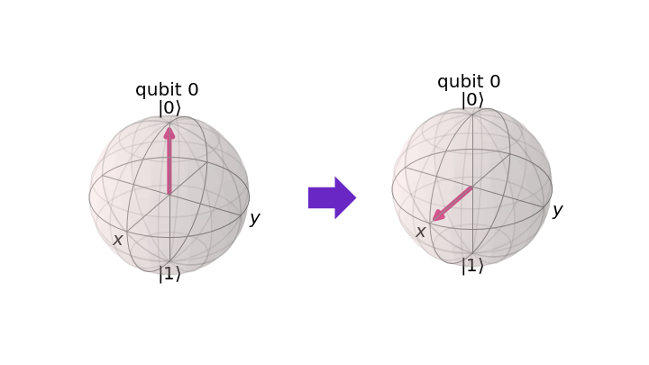

```python
# build your code here
answer3 = [4]
```

```python
# run this cell to submit your answer

# import the grader for the exercise 3 of the lab/badge 1
from qc_grader.challenges.quantum_explorers23 import grade_badge1_ex3

# expected result type: List
grade_badge1_ex3(answer3)
```

```
Submitting your answer. Please wait...
Thank you for submitting your answer. Your answer has been recorded and, if correct, will count towards your final score.
```

**Question 4: When two quantum particles are correlated such that a measurement on one immediately affects the other, it is called:**

1. Quantum Gates.
2. Quantum Entanglement.
3. Quantum Superposition.
4. Quantum Teleportation.

```python
# build your code here
answer4 = [2]
```

```python
# run this cell to submit your answer

# import the grader for the exercise 4 of the lab/badge 1
from qc_grader.challenges.quantum_explorers23 import grade_badge1_ex4

# expected result type: List
grade_badge1_ex4(answer4)
```

```
Submitting your answer. Please wait...
Thank you for submitting your answer. Your answer has been recorded and, if correct, will count towards your final score.
```

**Question 5: The goal is to reach the state $|-\rangle = \frac{1}{\sqrt{2}}(|0\rangle - |1\rangle)$. Which gate sequence do you apply?**

1. X gate -> Z gate.
2. H gate -> Z gate.
3. Z gate -> H gate.
4. H gate -> X gate.

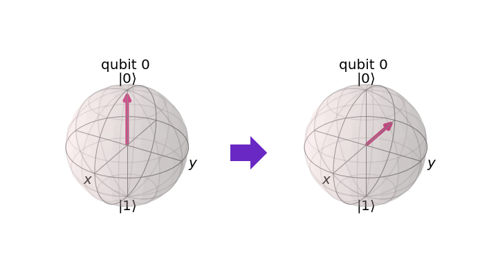

```python
# build your code here
answer5 = [2]
```

```python
# run this cell to submit your answer

# import the grader for the exercise 5 of the lab/badge 1
from qc_grader.challenges.quantum_explorers23 import grade_badge1_ex5

# expected result type: List
grade_badge1_ex5(answer5)
```

```
Submitting your answer. Please wait...
Thank you for submitting your answer. Your answer has been recorded and, if correct, will count towards your final score.
```

**Question 6: Which Qiskit code creates a quantum circuit called circ with 2 qubits and 2 classical bits?**

1. circ = QuantumCircuit(q = 2, c = 2).
2. QuantumCircuit(circ, 2, 2).
3. QuantumCircuit(name = circ, qubits = 2, bits = 2).
4. circ = QuantumCircuit(2,2).

```python
# build your code here
answer6 = [4]
```

```python
# run this cell to submit your answer

# import the grader for the exercise 6 of the lab/badge 1
from qc_grader.challenges.quantum_explorers23 import grade_badge1_ex6

# expected result type: List
grade_badge1_ex6(answer6)
```

```
Submitting your answer. Please wait...
Thank you for submitting your answer. Your answer has been recorded and, if correct, will count towards your final score.
```

**Question 7: Which circuit constructs the Bell state $|\phi^{+}\rangle = \frac{1}{\sqrt{2}}(|00\rangle + |11\rangle)$?**

1. Circuit A.
2. Circuit B.
3. Circuit C.
4. Circuit D.

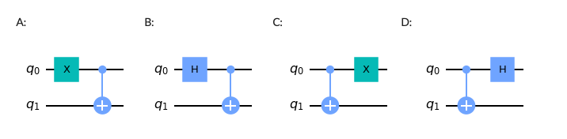

```python
# build your code here
answer7 = [2]
```

```python
# run this cell to submit your answer

# import the grader for the exercise 7 of the lab/badge 1
from qc_grader.challenges.quantum_explorers23 import grade_badge1_ex7

# expected result type: List
grade_badge1_ex7(answer7)
```

```
Submitting your answer. Please wait...
Thank you for submitting your answer. Your answer has been recorded and, if correct, will count towards your final score.
```

**Question 8: Which circuit constructs the Bell state $|\Psi^{+}\rangle = \frac{1}{\sqrt{2}}(|01\rangle + |10\rangle)$?**

1. Circuit A.
2. Circuit B.
3. Circuit C.
4. Circuit D.

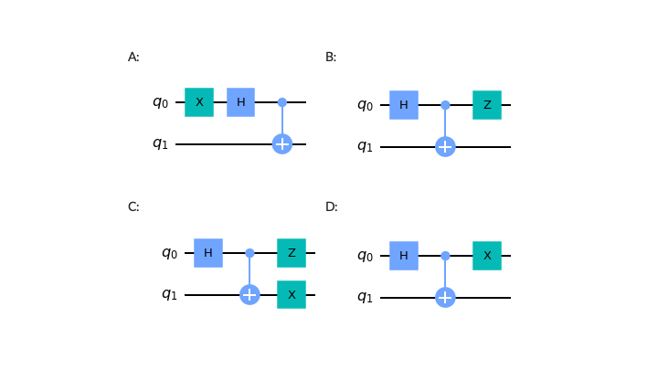

```python
# build your code here
answer8 = [4]
```

```python
# run this cell to submit your answer

# import the grader for the exercise 8 of the lab/badge 1
from qc_grader.challenges.quantum_explorers23 import grade_badge1_ex8

# expected result type: List
grade_badge1_ex8(answer8)
```

```
Submitting your answer. Please wait...
Thank you for submitting your answer. Your answer has been recorded and, if correct, will count towards your final score.
```

**Question 9: Which circuit constructs the GHZ-like state $|\Psi\rangle = \frac{1}{\sqrt{2}}(|010\rangle - |101\rangle)$ ?**

1. Circuit A.
2. Circuit B.
3. Circuit C.
4. Circuit D.

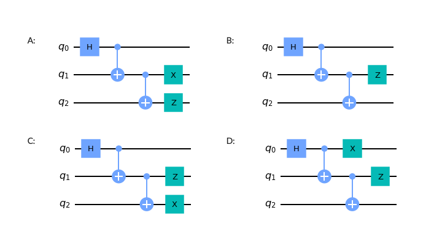

```python
# build your code here
answer9 = [1]
```

```python
# run this cell to submit your answer

# import the grader for the exercise 9 of the lab/badge 1
from qc_grader.challenges.quantum_explorers23 import grade_badge1_ex9

# expected result type: List
grade_badge1_ex9(answer9)
```

```
Submitting your answer. Please wait...
Thank you for submitting your answer. Your answer has been recorded and, if correct, will count towards your final score.
```

**Question 10: Alice's sending an unknown quantum state $|\psi\rangle$ (in purple) to Bob via quantum teleportation. She sends him two classical bits, $c_1c_0 = 10$, after performing her part of the algorithm. Which gate should Bob apply on his part of the Bell pair?**

1. Nothing.
2. X Gate.
3. Z Gate.
4. ZX Gate.

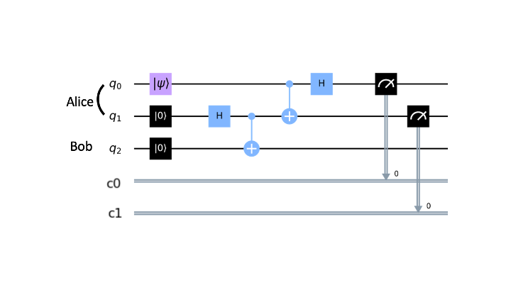

```python
# build your code here
answer10 = [2]
```

```python
# run this cell to submit your answer

# import the grader for the exercise 10 of the lab/badge 1
from qc_grader.challenges.quantum_explorers23 import grade_badge1_ex10

# expected result type: List
grade_badge1_ex10(answer10)
```

```
Submitting your answer. Please wait...
Thank you for submitting your answer. Your answer has been recorded and, if correct, will count towards your final score.
```

**Question 11: Which of the four states describes the state of the doorbells in Whiskerton?**

1. $\frac{1}{\sqrt{2}}(|00\rangle + |11\rangle)$.
2. $\frac{1}{\sqrt{2}}(|01\rangle + |10\rangle)$.
3. $\frac{1}{\sqrt{2}}(|00\rangle + |01\rangle)$.
4. $\frac{1}{\sqrt{2}}(|000\rangle + |111\rangle)$.

```python
# build your code here
answer11 = [1]
```

```python
# run this cell to submit your answer

# import the grader for the exercise 11 of the lab/badge 1
from qc_grader.challenges.quantum_explorers23 import grade_badge1_ex11

# expected result type: List
grade_badge1_ex11(answer11)
```

```
Submitting your answer. Please wait...
Thank you for submitting your answer. Your answer has been recorded and, if correct, will count towards your final score.
```

**Question 12: What would be the measurement results for a $|+\rangle$ quantum state?**

1. Random for both z and x measurements.
2. Random for a z measurement, 0 for an x measurement.
3. Random for a z measurement, 1 for an x measurement.
4. 0 for a z measurement, 1 for an x measurement.

```python
# build your code here
answer12 = [2]
```

```python
# run this cell to submit your answer

# import the grader for the exercise 12 of the lab/badge 1
from qc_grader.challenges.quantum_explorers23 import grade_badge1_ex12

# expected result type: List
grade_badge1_ex12(answer12)
```

```
Submitting your answer. Please wait...
Thank you for submitting your answer. Your answer has been recorded and, if correct, will count towards your final score.
```

### Qiskit Code Question

**Coding Question: Build a circuit with 4 qubits for the Qiskit logo state shown by the following Qsphere:**

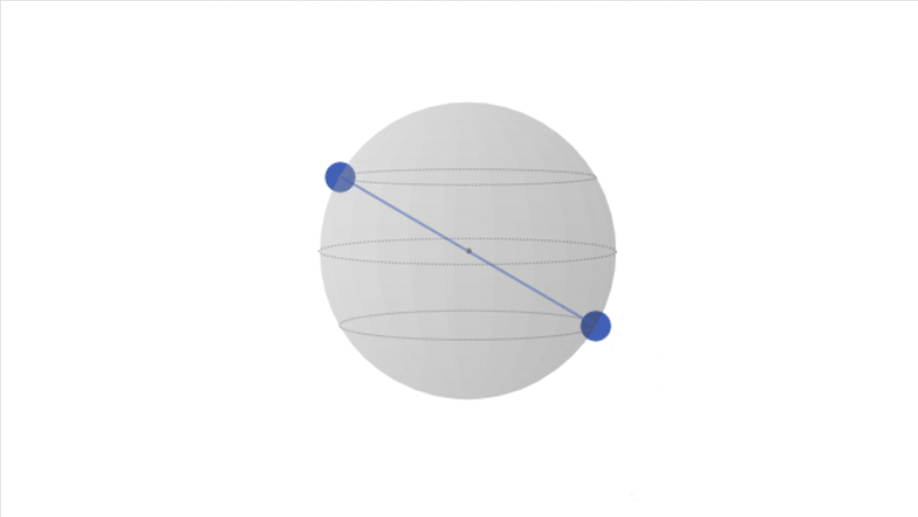

**Click to expand for hints.**

- Refer to the **[Qiskit documentation on the Qsphere](https://qiskit.org/documentation/stubs/qiskit.visualization.plot_state_qsphere.html)**
- Tweak the circuit until the Qsphere corresponding to your circuit matches the given Qsphere.

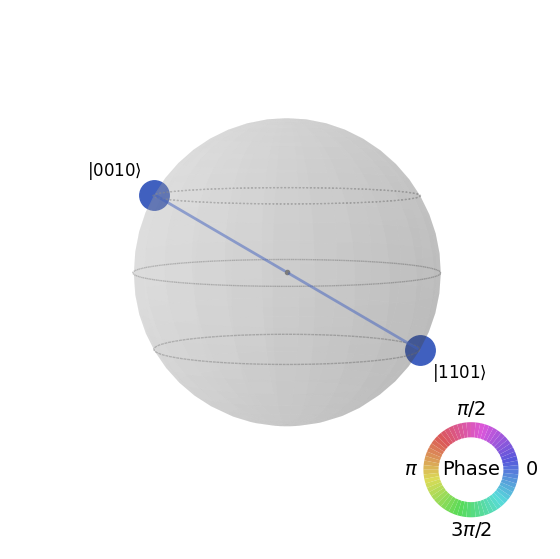

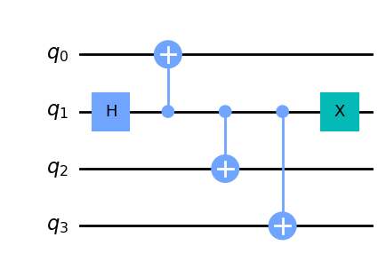

```python
# import the quantum circuit
# from the IBM's Qiskit library
from qiskit import QuantumCircuit

# import the plotting state of qsphere function
# from the IBM's Qiskit Visualization module
from qiskit.visualization import plot_state_qsphere


####### build your code below #########

# create a quantum circuit with
# a quantum register with 4 qubits
circuit = QuantumCircuit(4)

# apply the Hadamard gate to all the 4 qubits
# to see all the possible combinations of quantum states
# note: uncomment to see all the possible
#       combinations of quantum states
# circuit.h( [0, 1, 2, 3] )

# the (entangled) quantum state we need is
# |psi> = 1/sqrt(2) * ( |0010> + |1101> )

# apply the Hadamard gate to the 2nd qubit on
# the quantum register of the quantum circuit
circuit.h(1)


# apply the CX/CNOT gate on the 2nd qubit
# as control and on the 1st qubit as target,
# both on the quantum register of the quantum circuit
circuit.cx(1, 0)

# apply the CX/CNOT gate on the 2nd qubit
# as control and on the 3rd qubit as target,
# both on the quantum register of the quantum circuit
circuit.cx(1, 2)

# apply the CX/CNOT gate on the 2nd qubit
# as control and on the 4th qubit as target,
# both on the quantum register of the quantum circuit
circuit.cx(1, 3)


# apply the Pauli-X gate to the 2nd qubit on
# the quantum register of the quantum circuit
circuit.x(1)

####### build your code above #########


# display the plot of the quantum state from the QSphere
# applied to the quantum circuit defined before
display( plot_state_qsphere( circuit ) )

# draw the quantum circuit defined before
display( circuit.draw("mpl") )
```

```python
# run this cell to submit your answer

# import the grader for the coding exercise of the lab/badge 1
from qc_grader.challenges.quantum_explorers23 import grade_badge1_code

# expected result type: QuantumCircuit
answer_code = grade_badge1_code(circuit)
```

```
Submitting your answer. Please wait...
Congratulations! 🎉 Your answer is correct.
```

#### [Ungraded] Run your circuit on a simulator and a real device!

Run the cells below to run your quantum circuit on the Aer simulator and a real device and compare the results.

```python
#### get statevector from a quantum circuit ####

# import the statevector from the IBM's Qiskit
# Quantum Information module
from qiskit.quantum_info import Statevector

# retrieve the statevector from the instructions of
# the quantum circuit defined before
statevector = Statevector.from_instruction( circuit )
```

```
Statevector([0.        +0.j, 0.        +0.j, 0.70710678+0.j,
             0.        +0.j, 0.        +0.j, 0.        +0.j,
             0.        +0.j, 0.        +0.j, 0.        +0.j,
             0.        +0.j, 0.        +0.j, 0.        +0.j,
             0.        +0.j, 0.70710678+0.j, 0.        +0.j,
             0.        +0.j],
            dims=(2, 2, 2, 2))
Simulator Probability Distribution: {'1101': 0.5078125, '0010': 0.4921875}
```

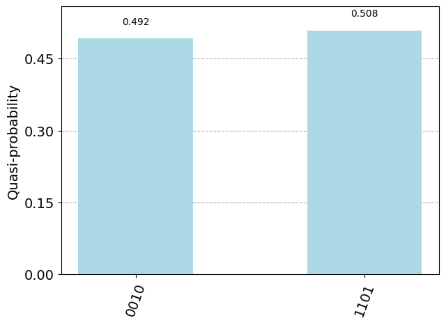

```python
#### run this cell to view the output of ####
#### your quantum circuit as a histogram ####

# import the Sampler from the IBM's Qiskit Aer Primitives module,
# with the 'AerSampler' alias being defined
from qiskit_aer.primitives import Sampler as AerSampler

# import the plot distribution function
# from the IBM's Qiskit Tools for Visualization module
from qiskit.tools.visualization import plot_distribution


#### run the circuit on the simulator ####
#### and get probability distribution ####


# create an Aer Sampler object
sampler = AerSampler()

# measure all the qubits from
# the quantum circuit defined before
circuit.measure_all()

# execute the quantum circuit defined before,
# on the Aer Sampler, retrieving the respective job
job = sampler.run(circuit)


# retrieve the probability distribution
# from the quasi-distribution of
# the results obtained from the execution of
# the quantum circuit created before
prob_distribution = job.result().quasi_dists[0].binary_probabilities()


# print the statevector from the instructions of
# the quantum circuit defined before
print( statevector )

# print the probability distribution
# from the quasi-distribution of
# the results obtained from the execution of
# the quantum circuit created before
print( "Simulator Probability Distribution:", prob_distribution )


# plot the probability distribution
# from the quasi-distribution of
# the results obtained from the execution of
# the quantum circuit created before
plot_distribution( prob_distribution, color=[ "lightblue" ] )
```

```python
# import the Qiskit's Runtime Service, Session, and Sampler
# from the Qiskit's IBM Runtime module
from qiskit_ibm_runtime import QiskitRuntimeService, Session, Sampler


# create a Qiskit's Runtime Service object,
# using the IBM Quantum channel
service = QiskitRuntimeService( channel="ibm_quantum" )

# retrieve the least busy backend
# (this step may take a while)
real_backend = service.least_busy( min_num_qubits=4, simulator=False )


# within the context of a session
with Session( service, backend=real_backend ) as session:

    # create the Sampler object for the Session defined before
    sampler = Sampler( session=session )

    # execute the quantum simulation of
    # the quantum circuit created before,
    # using the Sampler, and retrieving
    # the respective job on
    # a real quantum device
    job_real = sampler.run( circuit )
```

Depending on the queue of the quantum system, the job can take sometime to complete. You can monitor the status on the [Jobs' page](https://quantum-computing.ibm.com/jobs) or run the following cell.

```python
# retrieve and show the status of
# the job created for the execution of
# the quantum circuit defined before,
# on the Aer Sampler, using
# a real quantum device
job_real.status()
```

```
<JobStatus.QUEUED: 'job is queued'>
```

If your job has successfully completed, run the following cell to compare the measurement probability distribution of the simulator and the real quantum device.

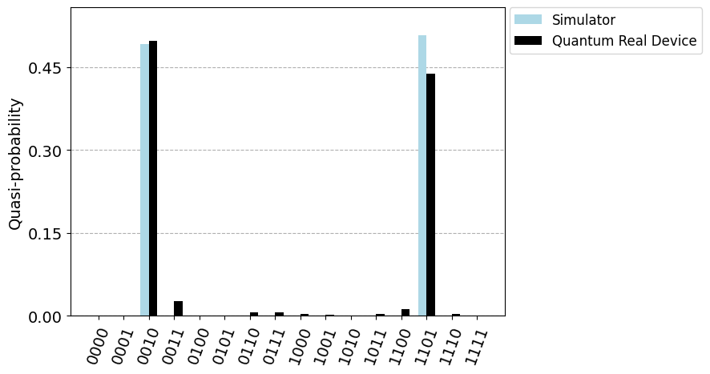

```python
# retrieve the probability distribution
# from the quasi-distribution of
# the results obtained from the execution of
# the quantum circuit created before,
# using a real quantum device
prob_distribution_real = job_real.result().quasi_dists[0].binary_probabilities()


# fix the probability distributions
# from the quasi-distributions of
# the results obtained from the execution of
# the quantum circuit created before,
# using the simulator, for values
# lower or equal to 0 (zero)
prob_distribution = { binary_string : prob if prob > 0 else 1e-8
                      for binary_string, prob in prob_distribution.items() }


# create a list with all the possible binary strings
# with 4 bits (i.e., a total of 16 possible different values)
binary_strings_4_bits = [ bin( num )[2:].zfill(4) for num in range( 2**4 ) ]


# for each possible binary string with 4 bits
for binary_string_4_bits in binary_strings_4_bits:

    # if the current binary string with 4 bits is
    # not in the diectionary of the probability
    # distributions from the quasi-distributions of
    # the results obtained from the execution of
    # the quantum circuit created before,
    # using the simulator
    if binary_string_4_bits not in prob_distribution:

        # add the missing binary string with 4 bits to
        # the diectionary of the probability
        # distributions from the quasi-distributions of
        # the results obtained from the execution of
        # the quantum circuit created before,
        # using the simulator, with a negligible value
        prob_distribution[ binary_string_4_bits ] = 1e-8


# fix the probability distributions
# from the quasi-distributions of
# the results obtained from the execution of
# the quantum circuit created before,
# using a real quantum device,
# for values lower or equal to 0 (zero)
prob_distribution_real = { binary_string : prob if prob > 0 else 1e-8
                           for binary_string, prob in prob_distribution_real.items() }


# plot the probability distributions
# from the quasi-distributions of
# the results obtained from the execution of
# the quantum circuit created before,
# using the simulator and a real quantum device
plot_distribution(
    data=[ prob_distribution, prob_distribution_real ],
    legend=[ "Simulator", "Quantum Real Device" ],
    color=[ "lightblue", "black" ],
    bar_labels = False
)
```

### Extra Credit Multiple Choice Questions

These questions are more advanced.

**Extra Credit Question A: Which circuit constructs the controlled-Y gate?**

1. Circuit A.
2. Circuit B.
3. Circuit C.
4. Circuit D.

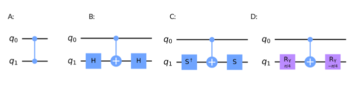

```python
# import the Quantum Circuit and the execute
# instruction from the IBM's Qiskit library
from qiskit import QuantumCircuit, execute

# import the Qiskit's Aer object
# from the IBM's Qiskit library
from qiskit import Aer


# retrieve the Unitary Simulator object
backend = Aer.get_backend( "unitary_simulator" )


######################################

#### for the 1st quantum circuit ####

# create the 1st quantum circuit,
# with a quantum register of 2 qubits
qc_1 = QuantumCircuit(2)


# apply the inverse of S gate on
# the 2nd qubit on the quantum register of
# the 1st quantum circuit created before
qc_1.sdg(1)

# apply the CX/CNOT gate on the 1st qubit
# as control and on the 2nd qubit as target,
# both on the quantum register of
# the 1st quantum circuit created before
qc_1.cx( 0, 1 )

# apply the S gate on the 2nd
# qubit on the quantum register of
# the 1st quantum circuit created before
qc_1.s(1)


# execute the quantum simulation of
# the 1st quantum circuit created before,
# and retrieve the respective job
job = execute( qc_1, backend, shots=10000 )

# retrieve the result obtained
# from the quantum simulation of
# the 1st quantum circuit created before
result = job.result()


# retrieve the unitary operator from the results
# obtained from the quantum simulation of
# the 1st quantum circuit created before
qc_1_unitary = result.get_unitary( qc_1, decimals = 3 )


######################################

#### for the 2nd quantum circuit ####

# create the 2nd quantum circuit,
# with a quantum register of 2 qubits
qc_2 = QuantumCircuit(2)


# apply the CY gate on the 1st qubit
# as control and on the 2nd qubit as target,
# both on the quantum register of
# the 2nd quantum circuit created before
qc_2.cy( 0, 1)


# execute the quantum simulation of
# the 2nd quantum circuit created before,
# and retrieve the respective job
job = execute( qc_2, backend, shots=10000 )

# retrieve the result obtained
# from the quantum simulation of
# the 2nd quantum circuit created before
result = job.result()


# retrieve the unitary operator from the results
# obtained from the quantum simulation of
# the 2nd quantum circuit created before
qc_2_unitary = result.get_unitary( qc_2, decimals = 3 )


# if the two quantum circuits are
# represented by the same unitary operator
if( qc_1_unitary == qc_2_unitary ):

    # print an informative success message,
    # in the case that the two quantum circuits
    # are represented by the same unitary operator
    print( "The two quantum circuits are represented by "
           "the same unitary operator!" )
```

```
The two quantum circuits are represented by the same unitary operator!
```

```python
# build your code here
answer13 = [3]
```

```python
# run this cell to submit your answer

# import the grader for the exercise 13 of the lab/badge 1
from qc_grader.challenges.quantum_explorers23 import grade_badge1_ex13

# expected result type: List
grade_badge1_ex13(answer13)
```

```
Submitting your answer. Please wait...
Thank you for submitting your answer. Your answer has been recorded and, if correct, will count towards your final score.
```

**Extra Credit Question B: Which quantum circuit finds 01 among 00, 01, 10, 11 in Grover's algorithm? The bit ordering is q1q0.**

1. Circuit A.
2. Circuit B.
3. Circuit C.
4. Circuit D.

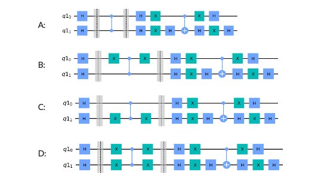

```python
# build your code here
answer14 = [3]
```

```python
# run this cell to submit your answer

# import the grader for the exercise 14 of the lab/badge 1
from qc_grader.challenges.quantum_explorers23 import grade_badge1_ex14

# expected result type: List
grade_badge1_ex14(answer14)
```

```
Submitting your answer. Please wait...
Thank you for submitting your answer. Your answer has been recorded and, if correct, will count towards your final score.
```

**Extra Credit Question C: Find the number of iterations with the largest amplitude when you run Grover's algorithm with one solution in a database with $N = 2^6$. Hint: Fewer than 12 times.**

1. 5.
2. 6.
3. 7.
4. 8.

```python
# build your code here
answer15 = [4]
```

```python
# run this cell to submit your answer

# import the grader for the exercise 15 of the lab/badge 1
from qc_grader.challenges.quantum_explorers23 import grade_badge1_ex15

# expected result type: List
grade_badge1_ex15(answer15)
```

```
Submitting your answer. Please wait...
Thank you for submitting your answer. Your answer has been recorded and, if correct, will count towards your final score.
```

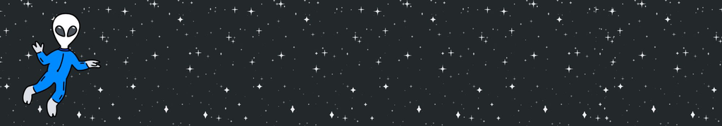

## Unlock Your Badge

Run the cell below to see whether you've passed the quiz. Passing score is 80%. If you have successfully passed, a password will be revealed. (Note: since there are extra credit questions, you may get over 100%!)

Please do not change the code in this cell.

```python
# run this cell to check whether you have passed

# import the grader for the badge 1 of
# the IBM Qiskit's Quantum Explorers 2023-2024
from qc_grader.challenges.quantum_explorers23 import grade_badge1_score

# grade the score of the quiz of the lab for the badge 1
grade_badge1_score("en")
```

```
Submitting your answer. Please wait...

Congratulations, Captain 🎉 🚀! You've passed with a percentage of 113.3%
You are now the Captain of Earth's first faster-than-light starship.

The password you are looking for is Interstellar! inclusive of the exclamation mark.
```

Have you passed? Congratulations!

Here's what you need to do to unlock your Captain achievement:

1. Download the Captain badge image from **[this link](https://ibm.box.com/s/4kqjemxqtvy1ojklkp0bz3ushas5n4j9)**. The link is password protected; enter the password revealed from the above cell.
2. Post the image to the **[#level-up channel on Discord](https://discord.com/channels/979714492533440533/1096012934829854720)** to get your shiny new Discord label! Please allow up to 5 business days for the badge label to show up under your Discord handle before querying an admin.

Made with ❤ by Rúben André Barreiro (and adapted from IBM Quantum).